# HW due 1.30.22 Soc 723 Ch. 6 and 7

Brenda Onyango

1/23/2022

## Chapter 6

1. The friend’s reasoning makes some sense as they have cases showing that height and income seem unrelated or maybe only *associated*, rather than causal. However, I would caution them to consider that causality doesn’t mean that every case of y (high income) is caused by x (height), but that as x changes (taller heights), then the *distribution* of y (income) changes; theoretically it’s possible to know people for which height didn’t lead to the $100K+ income while height still be a cause for income.

### Terry, Coin, and Cake

1. Variables with a direct effect on money are “CoinFlip” and “TerryInRoom.”
2. “Terry’sMood” is an indirect cause on “Money”.

### Harry Potter & Reading

1. The effect of “HarryPotterAsKid” on “ReadingAsAdult” is what we should include to answer the research question.
2. The indirect effects to include are “ReadOtherRowlingBooks” and a variable not pictured “PeersReading” to capture how the popularity of a book and reading could be about group or network membership.
3. The alternative explanation between reading Harry Potter and reading more as an adult is the latent variable pictured, which is “LikesReading” that leads to both reading Harry “PotterAsKid” and “ReadingAsAdult.” Other potential causal variables are “Parent’sReadingHabit” and “LiteracyEducation.” These two are probably more important predictor variables than “AgePotterReleased” since they affect ability to read and attitude towards reading. I say “AgePotterReleased” is not an important part of the data generating process as other variables because compelling, popular books are read long after their initial publication e.g., *The Lord of the Rings*, another popular fantasy, was initially published in 1954.
1. Including variables we’re unable to observe on our diagram gives us a fuller picture of the data generating process. “LikesReading” is a latent variable that we can’t observe and that can cause both the indepedent and dependent variable. Including latent variables in a diagram can also add to thinking about whether a relationship between two variables is a correlation or is causal. That “HarryPotterAsKid” has to occur before “ReadingAsAdult” can be support for interpreting this diagram as showing a causal relationship.
2. Latent variables cause both independent and dependent variables. LikesReading could precede and cause both reading Harry Potter as a kid and reading as an adult.

### Government Fire-Safety

5 a) Draw causal diagram with given features. Referenced: https://ggdag.malco.io/

```r
# install.packages("devtools")
devtools::install_github("malcolmbarrett/ggdag") #installing a package made for path diagrams
```

```r
library(ggdag) #loading package and ggplot2 to make diagram
library(ggplot2)
```

```r
firedag <- dagitty::dagitty("dag {
  GoodBudget <- ShortTimeSinceLastFire
  FireSafetyAds <- GoodBudget
  ParkRangers <- GoodBudget
  DecreaseForestFires <- FireSafetyAds
  DecreaseForestFires <- ParkRangers
  ShortTimeSinceLastFire [exposure]
  DecreaseForestFires [outcome]
}")

tidy_dag <- tidy_dagitty(firedag)

tidy_dag
```

```
## # A DAG with 5 nodes and 5 edges
## #
## # Exposure: ShortTimeSinceLastFire
## # Outcome: DecreaseForestFires
## #
## # A tibble: 6 × 8
##   name                       x     y direction to            xend  yend circular
##   <chr>                  <dbl> <dbl> <fct>     <chr>        <dbl> <dbl> <lgl>
## 1 FireSafetyAds           19.3  18.9 ->        DecreaseFor…  18.2  18.6 FALSE
## 2 GoodBudget              19.3  20.2 ->        FireSafetyA…  19.3  18.9 FALSE
## 3 GoodBudget              19.3  20.2 ->        ParkRangers   18.1  19.7 FALSE
## 4 ParkRangers             18.1  19.7 ->        DecreaseFor…  18.2  18.6 FALSE
## 5 ShortTimeSinceLastFire  20.1  21.3 ->        GoodBudget    19.3  20.2 FALSE
## 6 DecreaseForestFires     18.2  18.6 <NA>      <NA>          NA    NA   FALSE
```

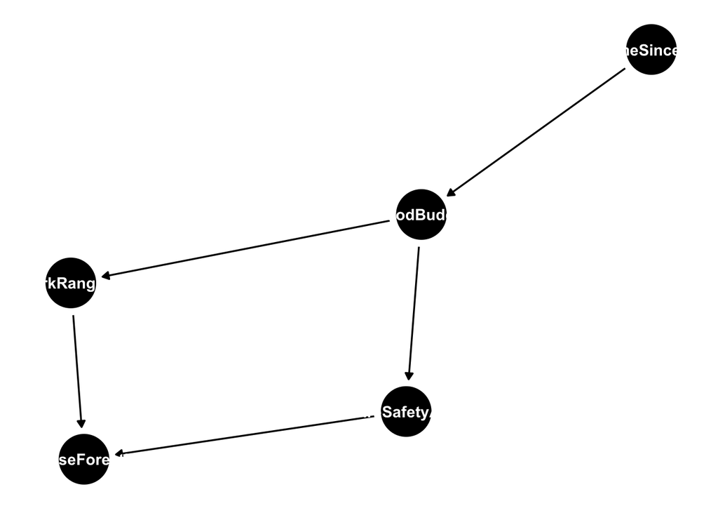

```r
ggdag(tidy_dag) + theme_dag() #visualizing diagram notice the font and nodes are small
```

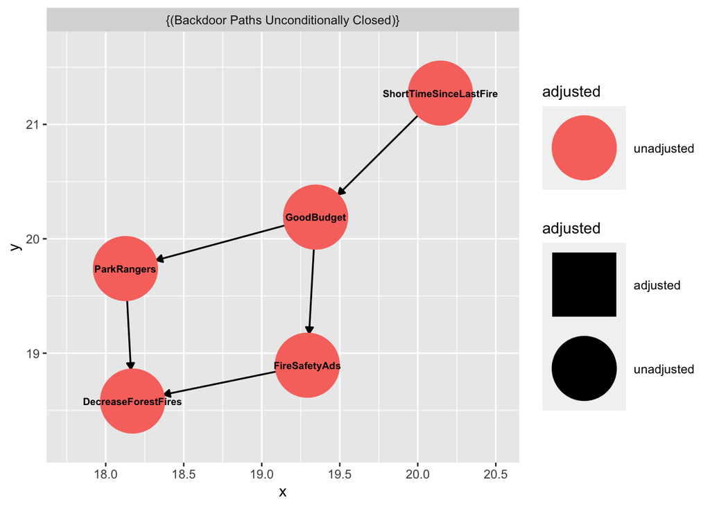

```r
ggdag_adjustment_set(tidy_dag, node_size = 21, text_size = 2.5, text_col = 'black') #adjusting size of nodes and colors for readability
```

2. One ommitted variable is ParkVisitorBehavior. An increase in ParkRangers could improve ParkVisitorBehavior and that could lead to DecreaseForestFires.

### Research Question in Sociology

6. A research question in the field of sociology is how does class affect individual health outcomes, namely lifespan, in the U.S.?
1. Data generating process includes the following assumptions:
1. Class is measured by income and class won’t change drastically across someone’s wokring life.
2. Class determines access to a health-promoting environment (housing near parks, far from pollution, access to gyms and this leads to health outcomes.
3. Class determines access to healthcare and this leads to lifespan.
4. Parents’ income may lead to both class and individual’s lifespan.
5. Individual risk behaviors lead to individual’s lifespan.
2. The cause of interest or independent variable is class and the outcome (dependent variable) is lifespan.
3. Other variables at play are occupation (different jobs have different mortality risks), smoking status (which might fall under individual risk behavior), social belonging (is an individual married, has friends, etc.), and net worth.

d & e) causal diagram with latent variables.

```r
lifedag <- dagitty::dagitty("dag {
  individualincome <- parentsincome
  lifespan <- parentsincome
  lifespan <- healthcareaccess
  livedenvironment <- individualincome
  lifespan <- livedenvironment
  healthcareaccess <- individualincome
  lifespan <- individualincome
  lifespan <- riskbehavior
  indivdiualincome [exposure]
  lifespan [outcome]
}")

tidy_dag2 <- tidy_dagitty(lifedag)

tidy_dag2
```

```
## # A DAG with 6 nodes and 8 edges
## #
## # Exposure: indivdiualincome
## # Outcome: lifespan
## #
## # A tibble: 9 × 8
##   name                 x     y direction to                xend  yend circular
##   <chr>            <dbl> <dbl> <fct>     <chr>            <dbl> <dbl> <lgl>
## 1 healthcareaccess  18.7 10.5  ->        lifespan          18.0  11.2 FALSE
## 2 individualincome  17.4 10.6  ->        healthcareaccess  18.7  10.5 FALSE
## 3 individualincome  17.4 10.6  ->        lifespan          18.0  11.2 FALSE
## 4 individualincome  17.4 10.6  ->        livedenvironment  16.7  11.4 FALSE
## 5 livedenvironment  16.7 11.4  ->        lifespan          18.0  11.2 FALSE
## 6 parentsincome     17.6  9.74 ->        individualincome  17.4  10.6 FALSE
## 7 parentsincome     17.6  9.74 ->        lifespan          18.0  11.2 FALSE
## 8 riskbehavior      18.6 12.6  ->        lifespan          18.0  11.2 FALSE
## 9 lifespan          18.0 11.2  <NA>      <NA>              NA    NA   FALSE
```

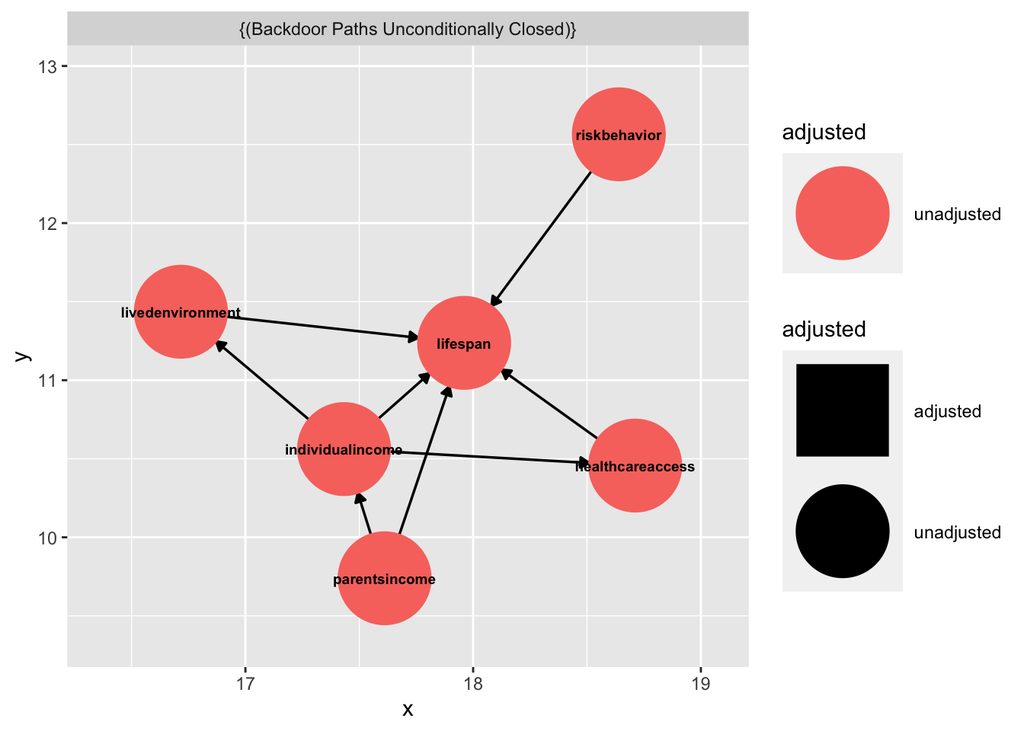

```r
ggdag_adjustment_set(tidy_dag2, node_size = 21, text_size = 2.5, text_col = 'black')
```

Risk behavior and parentsincome are latent variables displayed in the causal diagram above. I debated removing livedenvironment and healthcareaccess since they are mediators, but they are important to the question of the relationship between income and lifespan in the US. In a scenario where healthcareaccess is made universal then the causal link between income and lifespan may disappear; another important latent variable is healthcare economy (national, private, etc.). However, health policy experts often say only 10% (maybe up to 20%) of health outcomes for a population can be attributed to medical care so I can also see an argument to remove healthcareaccess from the diagram (source: https://nam.edu/social-determinants-of-health-101-for-health-care-five-plus-five/).

### Defining Causality

8. Causality describes a relationship between variables or events. To say that variable *A* causes *B* is saying that as the value of *A* changes, the distribution of *B* would also change.
9. 4. Causal diagram

## Chapter 7

1. 1. the diagram should include a variable for “number of celebrities in the cast” since having or not having celebrities could draw/repel viewers. I eliminated option c about not having “show budget” since this is a latent variable that affects both the ability to have celebrities in the cast and a marketing budget that can pull viewers, therefore, it is important to include.

### Shift Hours and Doctors

I interpreted this question as wanting us to add the additional features as we went along, rather than starting a new diagram each time.

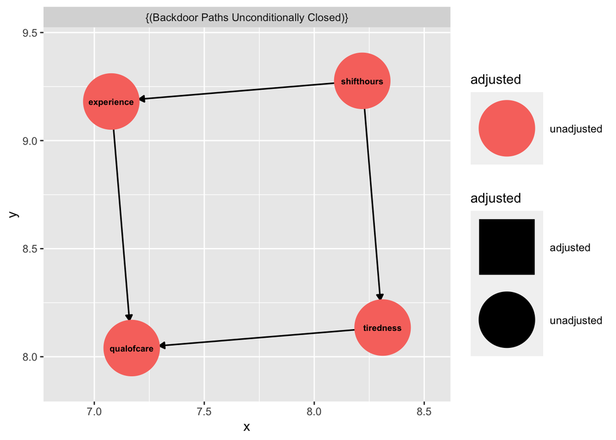

```r
docdagA <- dagitty::dagitty("dag {
  qualofcare <- experience
  qualofcare <- tiredness
  experience <- shifthours
  tiredness <- shifthours
  shifthours [exposure]
  qualofcare [outcome]
}")

tidy_dagA <- tidy_dagitty(docdagA)

ggdag_adjustment_set(docdagA, node_size = 21, text_size = 2.5, text_col = 'black')
```

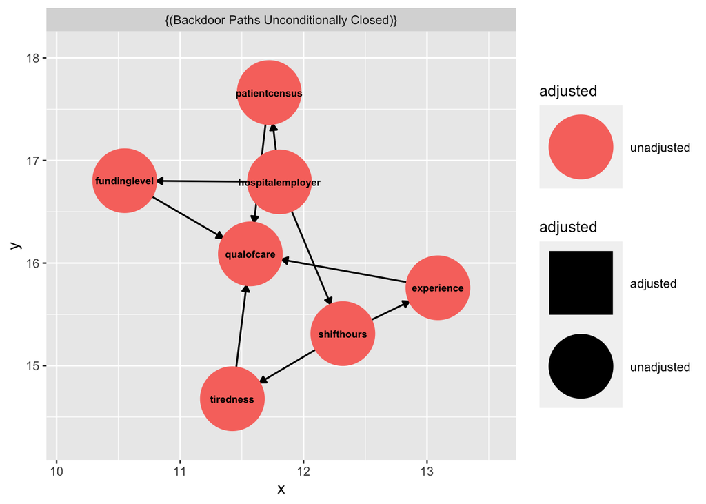

```r
docdagB <- dagitty::dagitty("dag {
  qualofcare <- fundinglevel <- hospitalemployer
  qualofcare <- patientcensus <- hospitalemployer
  qualofcare <- experience
  qualofcare <- tiredness
  shifthours <- hospitalemployer
  experience <- shifthours
  tiredness <- shifthours
  hospitalemployer [exposure]
  qualofcare [outcome]
}")

#patientcensus represents crowding variable
tidy_dagB <- tidy_dagitty(docdagB)

ggdag_adjustment_set(docdagB, node_size = 21, text_size = 2.5, text_col = 'black') #had to list hospitalemployer as the exposure to get an unconditionally closed path. leaving shifthours as exposure messes up the paths.
```

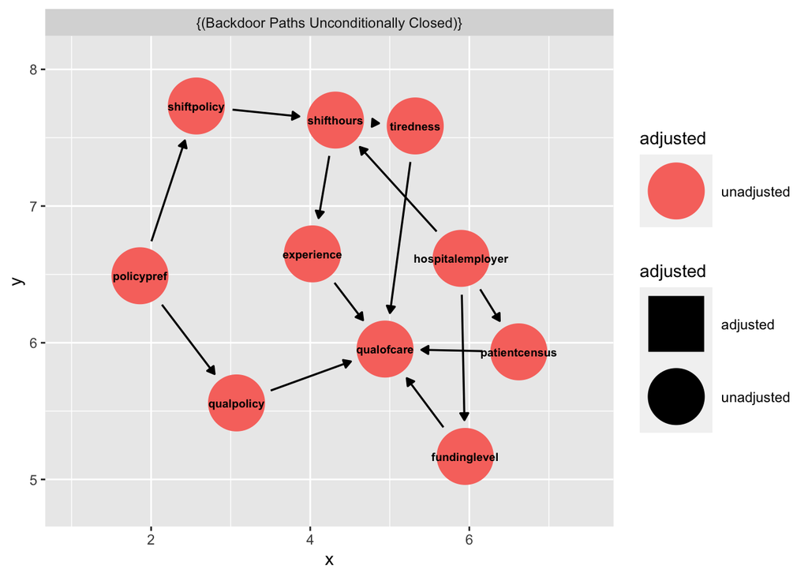

```r
docdagC <- dagitty::dagitty("dag {
  shiftpolicy <- policypref
  qualpolicy <-  policypref
  qualofcare <- qualpolicy
  shifthours <- shiftpolicy
  qualofcare <- fundinglevel <- hospitalemployer
  qualofcare <- patientcensus <- hospitalemployer
  qualofcare <- experience
  qualofcare <- tiredness
  shifthours <- hospitalemployer
  experience <- shifthours
  tiredness <- shifthours
  policypref [exposure]
  qualofcare [outcome]
}")

#patientcensus represents crowding variable
tidy_dagC <- tidy_dagitty(docdagC)

ggdag_adjustment_set(docdagC, node_size = 16, text_size = 2.5, text_col = 'black', label_col = text_col, node = TRUE) #adjusted node size to try to make sure arrows don't appear to overlap. Had to change exposure again even though exposure of interest is shifthours. Policypref is latent varaible.
```

### School Funding

1. The treatment is funding level of public schools and the outcome is student achievement for students in the country.
2. List of relevant variables:
1. student/teacher ratio. Lower student teacher ratios could help students achieve and the inverse could be true. I could separate this variable into two separate variables for student census and teacher census.
2. Average teacher experience. Student achievement could be explained by teacher experience. Average teacher experience will flucuate as there are new entrants (graduates, career switches) and turnover (retirement, exiting the field, promotion).
3. Inflation on teaching supplies. Inflation on supplies needed by schools to deliver education, like books, technology, heating costs, etc., can affect student achievement.
4. Participation in National School Lunch Program. Nutrition could affect student achievement and whether schools participate or not can affect students’ access to nutrition. (https://frac.org/wp-content/uploads/School-Meals-State-Legislation-Chart.pdf). Several states don’t mandate that schools participate in a meal program.
5. Parents home value. Lots of public schools base funding on property taxes which could change as the housing market changes or if anything happens to homes.
6. Whether a student is fluent in the language of instruction, is part of a marginalized group, has parents that can/’t afford tutoring, etc. can affect student achievement. I’ll simplify these variables as student’s SES.
3. I think parent’s home value causes both school funding and student achievement since home value is associated with parent’s wealth and parent’s wealth contributes to student SES and their achievement.
4. Parent’s home value is important to pay attention to since it could be a confounding variable; this would mean that funding level and student achievement have an association rather than being causally related.

e and f)

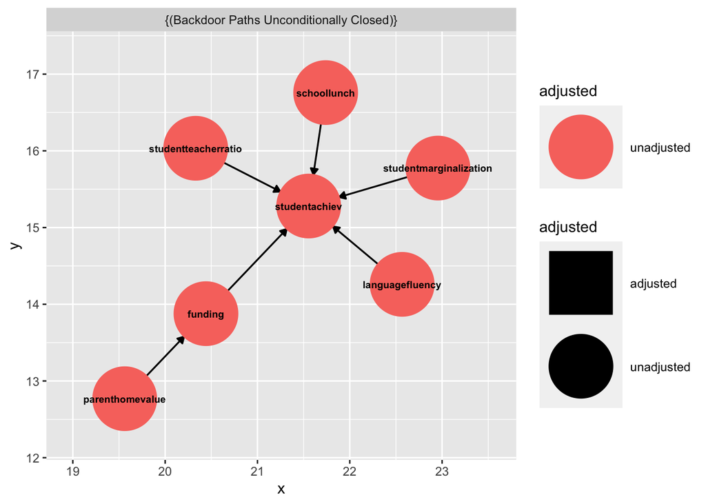

```r
schooldag <- dagitty::dagitty("dag {
  studentachiev <- funding <- parenthomevalue
  studentachiev <- languagefluency
  studentachiev <- studentmarginalization
  studentachiev <- studentteacherratio
  studentachiev <- schoollunch

  parenthomevalue [exposure]
  studentachiev [outcome]
}")


tidy_dag4 <- tidy_dagitty(schooldag)

ggdag_adjustment_set(schooldag, node_size = 21, text_size = 2.5, text_col = 'black')
```

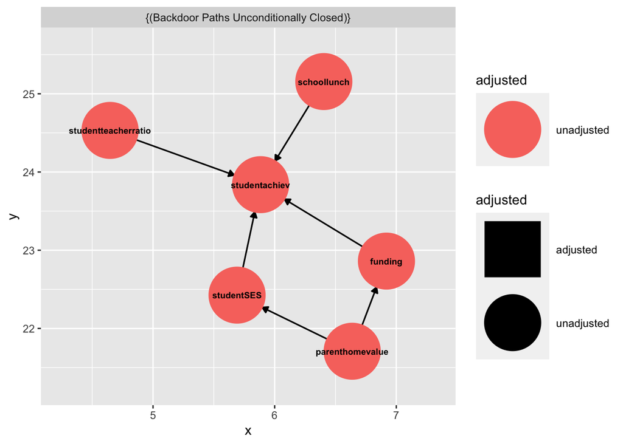

```r
schooldag2 <- dagitty::dagitty("dag {
  studentachiev <- funding <- parenthomevalue
  studentachiev <- studentSES
  studentachiev <- studentteacherratio
  studentSES <- parenthomevalue
  studentachiev <- schoollunch

  parenthomevalue [exposure]
  studentachiev [outcome]
}")


tidy_dag5 <- tidy_dagitty(schooldag2)

ggdag_adjustment_set(schooldag2, node_size = 21, text_size = 2.5, text_col = 'black')
```

```r
#SES is simplified version of language fluency, marginalization, etc.
```

I’m wondering if I should draw an arrow between funding and studentteacherratio since funding could affect ability to recruit teachers, but I’m ok with this diagram for now.